# The PISA Data

## By Senga Mukanda

## Introduction

The dataset that I chose to explore was the PISA 2012 assessment.

PISA is a survey of students' skills and knowledge as they approach the end of compulsory education. This survey examines

- how well students have learned the school curriculum,
- how well prepared they are for life beyond school.

PISA is a unique global survey that examines how well prepared 15 year old students are for life after they have completed school. Around 510,000 students in 65 economies took part in the PISA 2012 assessment of reading, mathematics and science. Of those economies, 44 took part in an assessment of creative problem solving and 18 in an assessment of financial literacy.

### What is the average score that the students obtained for each each subject?

- The first thing I want to look at is the students average score in the subjects that they wrote on.

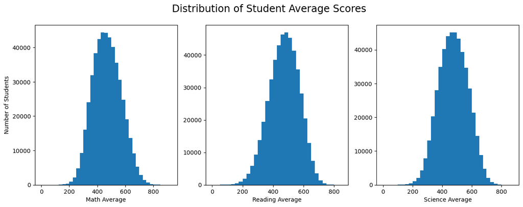

- From my graphs I can see that the average score for each subject is normally distrubuted as it has bell like shape meaning the information is normally distributed.
- By taking a closer look, I can also see that the average score for the students ranges between 400 to 600 points for each subject.

### Subject Averages Based on Gender

- Next I just want to have a look at how both gender perform against each other in the subjects overall average score.

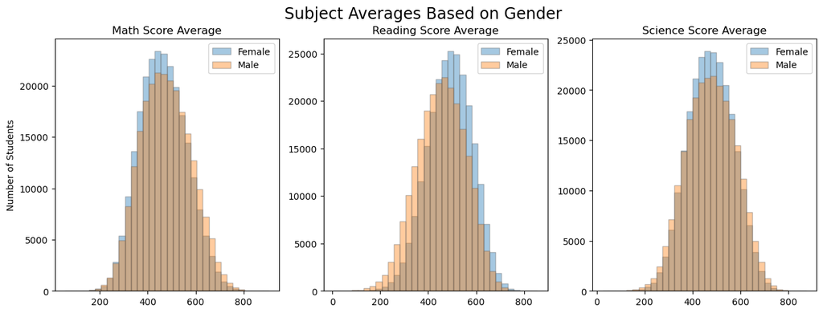

This graph shows me that:

- The females perform better in the reading than the males.
- The males perform better than the females in maths.
- They both perform equally in Science.

But the differnces is not that huge so in a way we can say that they are evenly matched.

### What is the correlation between the three subjects?

- Lastly I want to see how each subject correlate to one another.

```
<function matplotlib.pyplot.show(close=None, block=None)>
```

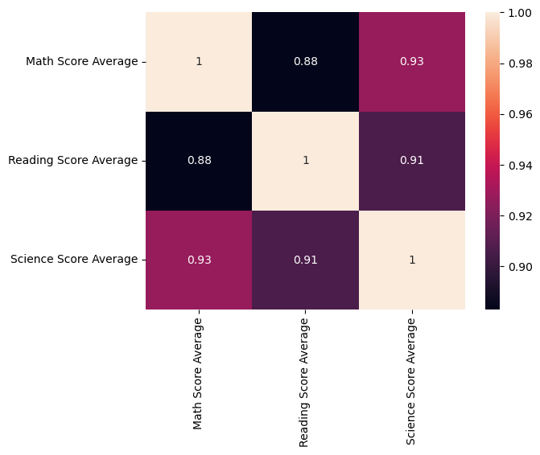

- As expected there is a solid, strong and positive correlation between any pair of the three subjects to the scores of the three subjects.
- Upon further inspection I see that even though they all have a strong positive correlation, the correlation between math and reading is the lowest and vice-versa. This could be because math isn't dependent on reading and vice_versa where as they both have an effect on the outcome of science. Because to be good in science you need to be good in both math and reading.

## Conclusion

- I learned that more females participated in the survey than males. Since the females performed better than the males when it came to Reading any country that had more female participants would have a better average in that.
- The male participants performed better than the females when it came to Math and so any country that had more male participants would have a better average in that.
- They performed evenly equal when it came to Science, so the overall average depended on the number of factors such as gender participation when it came to that. This is because science is a mixture of both reading and maths so if you have more females the average favors them and vice-versa.